# Deep Learning Summary

## Exercise 1

Tensorflow

## Exercise 2

- Activation functions

\begin{equation} \label{eq1} \begin{split} \text{ReLU}(x) & = max(0,x) \\ \tanh(x) & = \frac{e^x - e^{-x}}{e^x + e^{-x}} \\ \text{softmax}(x)_i & = \frac{e^{x_i}}{\sum_k e^{x_k}} \\ \tanh(\text{softmax}(x)) & = \tanh \left( \frac{e^{x_i}}{\sum_k e^{x_k}} \right) \end{split} \end{equation}

- Cross Entropy Loss Function

\begin{equation}\label{eq2} H(w) = \sum_{i=1}^n -y_i \log \hat{y}_i (x_i;w) - (1-y_i) \log(1-\hat{y}_i (x_i;w)) \end{equation}

- Log-likelihood

\begin{equation}\label{eq3} L(w) = \prod_{i=1}^n \hat{y}_i(x_i;w)^{y_i} \left( 1 - \hat{y}_i(x_i;w) \right)^{1-y_i} \end{equation}

## Exercise 3

- tanh(x) as a function of the sigmoid

\begin{equation} \label{eq4} \begin{split} tanh(x) & = \frac{e^x - e^{-x}}{e^x+e^{-x}} = \frac{e^x}{e^x} \cdot \frac{1-e^{-2x}}{1+e^{-2x}} \\ & = \frac{1-1 + 1-e^{-2x}}{1+e^{-2x}} \\ & = \frac{2-1-e^{-2x}}{1+e^{-2x}} = \frac{2-\left(1+e^{-2x}\right)}{1+e^{-2x}} = \frac{2}{1+e^{-2x}} - \frac{1+e^{-2x}}{1+e^{-2x}} \\ & = 2 \cdot \sigma \left(2x \right) -1 \end{split} \end{equation}

- Taylor-Lagrange: Expansion of $f \in C^{n+1}\left(\left[a,b\right],\mathbb{R} \right)$ around a point $x_0 \in \left(a,b\right)$

\begin{equation} f(x) = \sum_{k=0}^n \frac{f^{(k)}(x_0)}{k!}\left(x-x_0\right)^k + \int_{x_0}^x \frac{f^{(n+1)}t}{n!} \left(x-t\right)^n \mathrm{d}t \end{equation}

- Integration by Parts

\begin{equation} \int_a^b u(x)v'(x)\mathrm{d}x = u(x) v(x) \Big|_a^b - \int_a^b u'(x)v(x)\mathrm{d}x \end{equation}

- Weierstrass Theorem

If $f(x)$ is a given continuous function for $a \leq x \leq b$ and if $\epsilon > 0$, it is possible to construct an approximating polynomial $P(x)$ such that

\begin{equation} P_n(x) = \frac{1}{J_n} \int_0^1 f(t) \left[ 1- (t-x)^2 \right]^n \mathrm{d}t \end{equation}

where $J_n = \int_{-1}^1 (1-u^2)^n \mathrm{d}u$ is a constant.

## Exercise 4

### Backpropagation and Computational Graphs

Remember chain rule

### Approximate the Hessian for Feed Forward Networks

With $a_j$ are the values of layer $j$, $a_i$ are the values of layer $i$, $w_{ji}$ are the weights connecting layer $i$ to layer $j$. The values $a_j$ of layer $j$ are defined as

\begin{equation} a_j = \sum w_{ji} z_i = \sum w_{ji} h(a_i) \end{equation}

where $h$ is the nonlinear activation function. Therefore the

\begin{equation} \frac{\partial^2 L_n}{\partial w_{ji}^2} = \frac{\partial^2 L_n}{\partial a_j^2} \cdot z_i^2 \end{equation}

### Chain Rule and Jacobian for Tensors

Let $y(W) = Wx + b$ where $W \in \mathbb{R}^{d_1 \times d_2}$ and $ b \in \mathbb{R}^{d_3}$. Furhter let $L(y): \mathbb{R}^{d_3} \mapsto \mathbb{R}$. Then the Jacobian can be expressed as:

\begin{equation} \frac{\partial L}{\partial W} = \frac{\partial L}{\partial y} \times \frac{\partial y}{\partial W} \end{equation}

I. e. differentiate each $y_i$ with respect to W and sum up. In the Jacobian this results in

\begin{equation} \frac{\partial L}{\partial W_{jk}} = \sum_i \frac{\partial L}{\partial y_i} \frac{\partial y_i}{\partial W_{jk}} \end{equation}

for each entry.

## Exercise 5

### Properties of Convolutional Layers

Output of a convolutional layer

\begin{equation} (f*k)(x,y) = \sum_{u = -p}^{p} \sum_{v=-q}^{q} f(x-u,y-v)k(u,v) \end{equation}

where $f \in \mathbb{R}^{m \times n}$ represents an impage and $k(u,v) \in \mathbb{R}^{2p+1 \times 2q+1}$ represents a 2D kernel. We can show that convolution is invariant, i. e. $\tau_{(s,t)}(f*k) = \left(\tau_{(s,t)}f\right)*k$, to translation $\left( \tau_{(s,t)}f\right)(x,y) = f(x-s,y-t)$. Also the size of the convolution output is smaller, i. e. $(m - 2p) \times (n - 2q)$.

### Local connectivity and parameter sharing in CNNs

I don't understand this task.

### Backpropagation through convolutional layers

### CNNs in tensorflow

```python
from __future__ import absolute_import
from __future__ import division
from __future__ import print_function

# Imports
import numpy as np
import tensorflow as tf

print(tf.__version__)

tf.logging.set_verbosity(tf.logging.INFO)

# Our application logic will be added here
```

```
1.12.0
```

## Exercise 6

### Fundamentals of Unconstrained Optimization

Check if local minimum: Hessian should fulfill Sylvester's Criterion, i. e. the determinants starting from left top, should be positive. If one of these determinants is not positive, it is a saddle point. Of course, the first derivative should be zero.

### Gradient Descent step derivation

The gradient step

\begin{equation} s_t := w_{t+1} - w_t = -\frac{1}{L} \nabla f(w_t), L > 0 \end{equation}

minimizes a quadratically regularized first order Taylor expansion of the objective $f$ around the current iterate $w_t$. This is, minimize the function

\begin{equation} m_t(s) = f(w_t) +s^T \nabla f(w_t) + \frac{L}{2} \|s \|_2^2 \end{equation}

### Optimization methods in TensorFlow

Three of the most common optimization methods in deep learning: Stochastic Gradient Descent (SGD), Adagrad, and Adam!

vAs shown by the formulas, Adagrad uses individual step sizes for every parameter, which depend on the history of its gradients. The intuiton here is that the learning rate decays faster for dimensions that have already seen significatn updates.

Tensorflow MNIST Example and Optimization implementation

```python
import os
import time
import tensorflow as tf
tf.enable_eager_execution()
```

```python
batch_size = 32
tf.set_random_seed(42)

# load mnist images and store them in two seperate tensorflow dataset (train and test)
(x_train, y_train),(x_test, y_test) = tf.keras.datasets.mnist.load_data()
x_train, x_test = x_train / 255.0, x_test / 255.0

# tf.cast: Casts a tensor to a new type.
# tf.data.DataSet.from_tensor_slices: Creates a Dataset whose elements are slices of the given tensors.
y_train, y_test = tf.cast(y_train, dtype=tf.int32), tf.cast(y_test, dtype=tf.int32)
dset_train = tf.data.Dataset.from_tensor_slices((x_train, y_train)).shuffle(100, reshuffle_each_iteration=True).repeat().batch(batch_size)
dset_test = tf.data.Dataset.from_tensor_slices((x_test, y_test)).shuffle(100, reshuffle_each_iteration=True).repeat().batch(1000)
```

```python
class Model(tf.keras.Model):
    '''We use a simple model with only one hidden fully connected layer.
    More complex architectures can achieve higher accuracies, see http://yann.lecun.com/exdb/mnist/.'''
    def __init__(self, units=128):
        super(Model, self).__init__()
        self.units = units
        self.W1 = tf.layers.Dense(units, activation=tf.nn.relu, name="Layer1")
        self.W2 = tf.layers.Dense(10, name="Layer2")

    def call(self, _input):
        '''One forward pass of the model with a batch of MNIST images as the input x (shape: [32, 28x28x]) and
        logits for each class label as the output (shape: [32, 10]).'''
        x = tf.layers.flatten(_input)
        hidden1 = self.W1(x)
        logits = self.W2(hidden1)
        return logits


def loss(logits, labels):
    '''Cross entropy loss between the predicted (soft) assignments and the true target labels.'''
    return tf.reduce_mean(
      tf.nn.sparse_softmax_cross_entropy_with_logits(
          logits=logits, labels=labels))


def compute_accuracy(logits, labels):
    predictions = tf.argmax(logits, axis=1, output_type=tf.int64)
    labels = tf.cast(labels, tf.int64)
    batch_size = int(logits.shape[0])
    return tf.reduce_sum(
      tf.cast(tf.equal(predictions, labels), dtype=tf.float32)) / batch_size


def train(model, optimizer, dataset, dataset_test, log_interval=100, stop=500):
    """Trains model on `dataset` using `optimizer`."""
    start = time.time()
    loss_gian = []
    for (batch, (images, labels)) in enumerate(dataset):

        # tape records operations for automatic differentiation
        with tf.GradientTape() as tape:
            logits = model(images)
            loss_value = loss(logits, labels)

        # compute the gradients and use them to optimize the model variables
        grads = tape.gradient(loss_value, model.variables)
        optimizer.apply_gradients(zip(grads, model.variables))

        if log_interval and batch % log_interval == 0:
            rate = log_interval / (time.time() - start) if batch > 0 else 1./(time.time() - start)
            print('Step #%d\tLoss: %.6f (%d steps/sec)' % (batch, loss_value, rate))
            start = time.time()
        if batch % 100 == 0:
            loss_ret = test(model, dataset_test)
            loss_gian.append(loss_ret)
        if batch >= stop: break
    return loss_gian

def test(model, dataset):
    """Perform an evaluation of `model` on the examples from `dataset`."""
    avg_loss = 0
    avg_accuracy = 0
    for (images, labels) in dataset:
        logits = model(images)
        avg_loss = loss(logits, labels)
        accuracy = tf.reduce_mean(tf.cast(tf.equal(tf.argmax(logits, axis=1, output_type=tf.int32),labels), tf.float32))
        break
    print('Test set: Average loss: {0:.3f}, Accuracy: {1:.1f}%\n'.format(avg_loss.numpy(), 100 * accuracy.numpy()))
    return avg_loss.numpy()
```

SGD Update step: \begin{equation} w_{t+1} = w_t - \eta \nabla_{w_t} l\left(x_t, w_t\right) \end{equation}

where $x_t$ is a randomly sampled batch of the data and $l()$ is the loss function.

```python
class SGD:
    def __init__(self, learning_rate=0.01):
        self.learning_rate = learning_rate

    def apply_gradients(self, grads_and_vars):
        for gradient, variable in grads_and_vars:
            variable.assign_sub(self.learning_rate*gradient)
```

AdaGrad Update step:

\begin{equation} \begin{split} g_t & = \nabla_w l \left( x_t, w_t \right) \\ G_t & = G_{t-1} + g_t \cdot g_t^T \in \mathbb{R}^{n \times n} \\ w_{t+1} & = w_t - \eta \cdot \text{diag} \left( G_t + \epsilon I \right)^{-0.5} \cdot g_t \end{split} \end{equation}

initial_accumulator_value $:= \epsilon$

```python
class Adagrad:
    def __init__(self, learning_rate=0.001, initial_accumulator_value=0.1):
        self.learning_rate = learning_rate
        self.initial_accumulator_value = initial_accumulator_value
        self.g = None

    def apply_gradients(self, grads_and_vars):
        if self.g is None:
            grads_and_vars = list(grads_and_vars)
            self.g = [tf.ones_like(gradient_layer, dtype=tf.float64) * self.initial_accumulator_value for (gradient_layer, _) in grads_and_vars]

        for i, (gradient, variable) in enumerate(grads_and_vars):
            self.g[i] += tf.square(gradient)
            variable.assign_sub(self.learning_rate/tf.sqrt(self.g[i])*gradient)
```

Adam Update Step:

```python
class Adam:
    def __init__(self, learning_rate=0.001, beta1=0.9, beta2=0.999, epsilon=1e-08):
        self.learning_rate = learning_rate
        self.beta1 = beta1
        self.beta2 = beta2
        self.epsilon = epsilon
        self.m = None
        self.v = None
        self.iteration = 0

    def apply_gradients(self, grads_and_vars):
        self.iteration += 1
        if self.m is None:
            grads_and_vars = list(grads_and_vars)
            self.m = [tf.zeros_like(gradient_layer, dtype=tf.float64) for (gradient_layer, _) in grads_and_vars]
            self.v = [tf.zeros_like(gradient_layer, dtype=tf.float64) for (gradient_layer, _) in grads_and_vars]

        learning_rate = self.learning_rate * tf.cast(tf.sqrt(1-self.beta2**self.iteration)/(1-self.beta1**self.iteration), dtype=tf.float64)

        for i, (gradient, variable) in enumerate(grads_and_vars):
            self.m[i] = self.beta1 * self.m[i] + (1 - self.beta1) * gradient
            self.v[i] = self.beta2 * self.v[i] + (1 - self.beta2) * tf.square(gradient)
            update_step = learning_rate / (tf.sqrt(self.v[i]) + self.epsilon) * self.m[i]
            variable.assign_sub(update_step)
```

```python
# Set a fixed random seed, so you can compare your implementation against the provided tensorflow optimizer.
tf.set_random_seed(42)

model = Model()

"""Use your own implementation of the optimizer."""
optimizer = SGD(learning_rate=0.01)
# optimizer = Adagrad(learning_rate=0.1)
# optimizer = Adam(learning_rate=0.01)

"""Use a pre-built one from tensorflow. Compare your solution against these given optimizers."""
# optimizer = tf.train.GradientDescentOptimizer(learning_rate=0.01)
# optimizer = tf.train.AdagradOptimizer(learning_rate=0.1)
# optimizer = tf.train.AdamOptimizer(learning_rate=0.01)

loss_gian1 = train(model, optimizer, dset_train, dset_test, stop=1000)
```

```
Step #0	Loss: 2.361418 (32 steps/sec)
Test set: Average loss: 2.405, Accuracy: 11.6%

Step #100	Loss: 1.574286 (81 steps/sec)
Test set: Average loss: 1.669, Accuracy: 60.0%

Step #200	Loss: 0.956167 (82 steps/sec)
Test set: Average loss: 1.201, Accuracy: 72.2%

Step #300	Loss: 0.751621 (83 steps/sec)
Test set: Average loss: 0.943, Accuracy: 78.6%

Step #400	Loss: 0.632681 (81 steps/sec)
Test set: Average loss: 0.805, Accuracy: 80.6%

Step #500	Loss: 1.067699 (79 steps/sec)
Test set: Average loss: 0.709, Accuracy: 82.7%

Step #600	Loss: 0.597220 (78 steps/sec)
Test set: Average loss: 0.631, Accuracy: 84.4%

Step #700	Loss: 0.585553 (76 steps/sec)
Test set: Average loss: 0.579, Accuracy: 85.5%

Step #800	Loss: 0.266709 (68 steps/sec)
Test set: Average loss: 0.547, Accuracy: 86.2%

Step #900	Loss: 0.350280 (72 steps/sec)
Test set: Average loss: 0.512, Accuracy: 86.3%

Step #1000	Loss: 0.534855 (68 steps/sec)
Test set: Average loss: 0.485, Accuracy: 86.7%
```

```python
tf.set_random_seed(42)

model = Model()

"""Use your own implementation of the optimizer."""
# optimizer = SGD(learning_rate=0.01)
# optimizer = Adagrad(learning_rate=0.1)
optimizer = Adam(learning_rate=0.01)

"""Use a pre-built one from tensorflow. Compare your solution against these given optimizers."""
# optimizer = tf.train.GradientDescentOptimizer(learning_rate=0.01)
# optimizer = tf.train.AdagradOptimizer(learning_rate=0.1)
# optimizer = tf.train.AdamOptimizer(learning_rate=0.01)

loss_gian2 = train(model, optimizer, dset_train, dset_test, stop=1000)
```

```
Step #0	Loss: 2.361418 (14 steps/sec)
Test set: Average loss: 2.261, Accuracy: 29.2%

Step #100	Loss: 0.170871 (110 steps/sec)
Test set: Average loss: 0.335, Accuracy: 89.9%

Step #200	Loss: 0.039924 (104 steps/sec)
Test set: Average loss: 0.373, Accuracy: 88.5%

Step #300	Loss: 0.121728 (96 steps/sec)
Test set: Average loss: 0.346, Accuracy: 88.3%

Step #400	Loss: 0.505539 (97 steps/sec)
Test set: Average loss: 0.331, Accuracy: 90.4%

Step #500	Loss: 0.557151 (100 steps/sec)
Test set: Average loss: 0.212, Accuracy: 93.5%

Step #600	Loss: 0.077901 (97 steps/sec)
Test set: Average loss: 0.172, Accuracy: 94.0%

Step #700	Loss: 0.404447 (95 steps/sec)
Test set: Average loss: 0.265, Accuracy: 91.6%

Step #800	Loss: 0.209628 (84 steps/sec)
Test set: Average loss: 0.216, Accuracy: 92.9%

Step #900	Loss: 0.150865 (81 steps/sec)
Test set: Average loss: 0.295, Accuracy: 91.0%

Step #1000	Loss: 0.325966 (82 steps/sec)
Test set: Average loss: 0.175, Accuracy: 94.4%
```

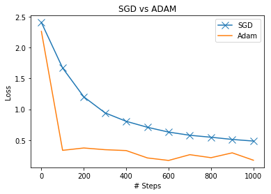

```python
import matplotlib.pyplot as plt

x = np.arange(len(loss_gian1))*100

plt.plot(x,loss_gian1,label='SGD',marker='x', markersize=10)
plt.plot(x,loss_gian2,label='Adam')

plt.xlabel('# Steps')
plt.ylabel('Loss')
plt.title('SGD vs ADAM')
plt.legend()

plt.show()
```